# People

Principal Investigators

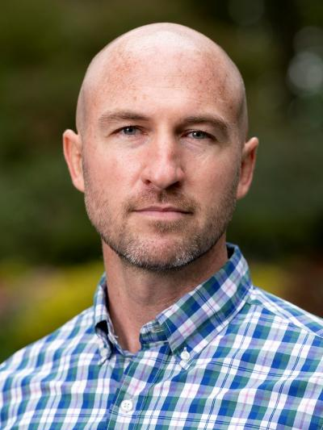

**Shaun Truelove**  
Assistant Scientist  
Departments of Epidemiology and International Health  
Johns Hopkins Bloomberg School of Public Health

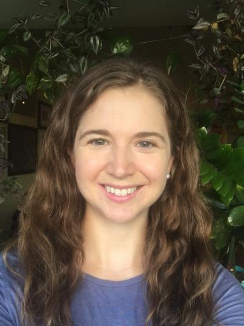

**Alison Hill**  
Assistant Professor  
Department of Biomedical Engineering  
Johns Hopkins University School of Medicine

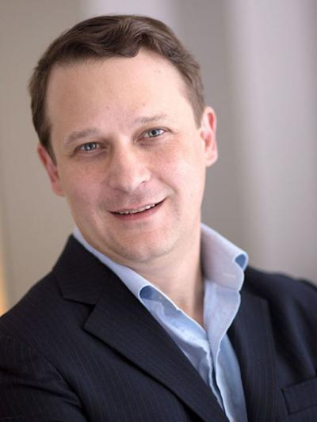

**Justin Lessler**  
Professor  
Department of Epidemiology  
Gillings School of Global Public Health  
University of North Carolina at Chapel Hill

Staff

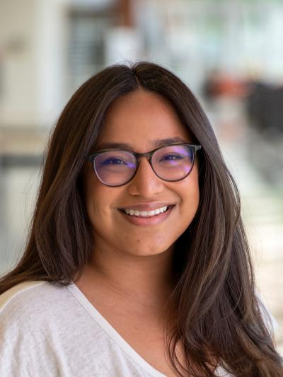

**Erica Carcelen**  
Research Project Manager  
Department of International Health  
Johns Hopkins Bloomberg School of Public Health

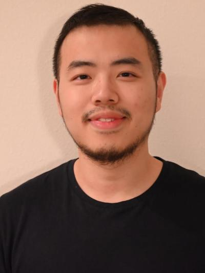

**Pengcheng Fang**  
Software Engineer  
Department of Epidemiology  
Johns Hopkins Bloomberg School of Public Health

[figure not shown]

**Koji Sato**  
Senior Software Engineer  
Department of International Health  
Johns Hopkins Bloomberg School of Public Health

Students, Fellows, & Researchers

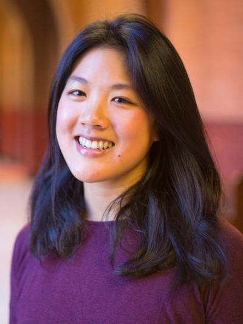

**Elizabeth Lee**  
Research Associate  
Department of Epidemiology  
Johns Hopkins Bloomberg School of Public Health

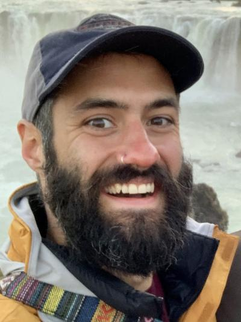

**Clifton McKee**  
Research Associate  
Department of Epidemiology  
Johns Hopkins Bloomberg School of Public Health

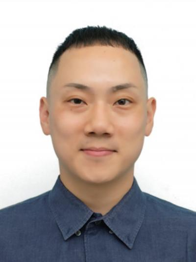

**Sung-mok Jung**  
Postdoctoral Fellow  
Carolina Population Center  
University of North Carolina at Chapel Hill

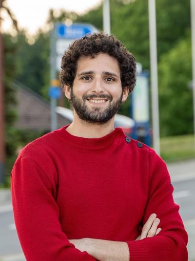

**Joseph Lemaitre**  
Postdoctoral Fellow  
Department of Epidemiology  
Gillings School of Global Public Health  
University of North Carolina at Chapel Hill

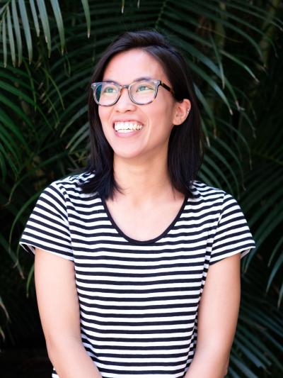

**Sara Loo**  
Postdoctoral Fellow  
Department of International Health  
Johns Hopkins Bloomberg School of Public Health

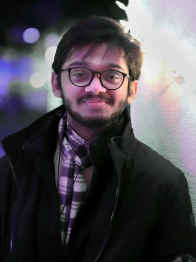

**Heramb Gupta**  
MSE Candidate  
Department of Biomedical Engineering  
Johns Hopkins Whiting School of Engineering

[figure not shown]

**Claire Smith**  
PhD Candidate  
Department of International Health  
Johns Hopkins Bloomberg School of Public Health

| Alumni |
| --- |
| Kyra Grantz Juan Dent Hulse Joshua Kaminsky Kathryn Kaminsky Stephen Lauer Lindsay Keegan Hannah Meredith Javier Perez-Saez Sam Shah Josh Wills |